# Empire, Discipline, Field

Imaginary and Possible Futures for Cultural Evolution

Stephen Vaisey

Duke University

# Who am I?

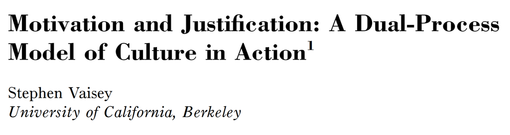

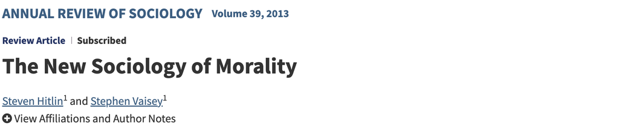

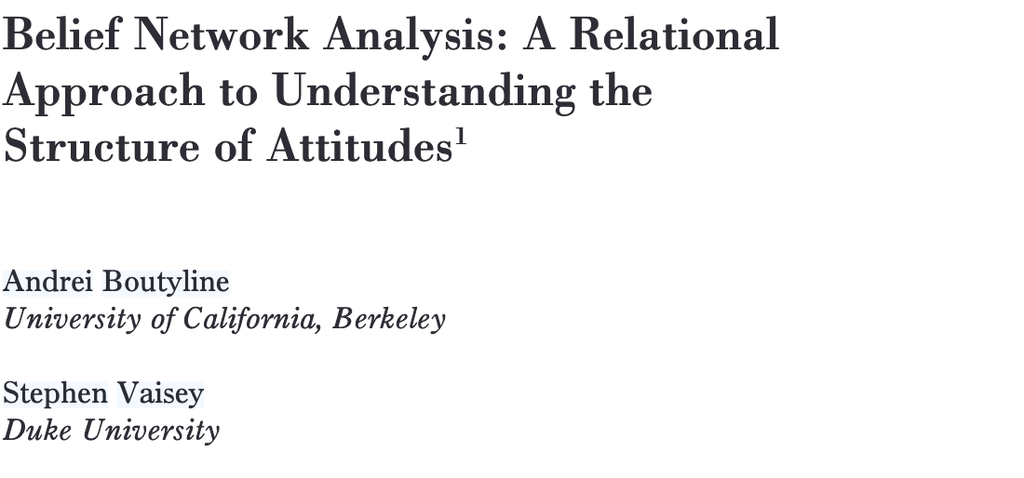

[figure not shown]

[figure not shown]

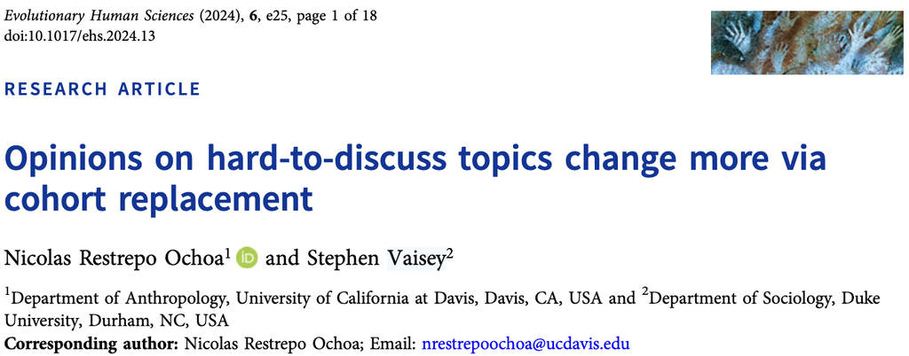

# How did I get here?

# Why sociology?

[figure not shown]

[figure not shown]

[figure not shown]

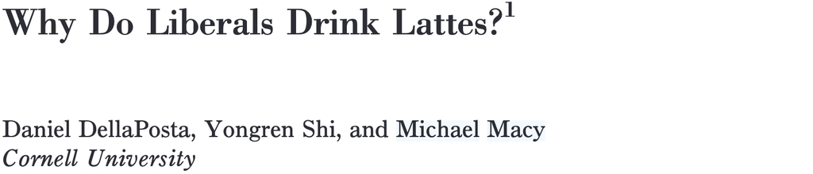

[figure not shown]

# Imagined or possible futures

[figure not shown]

[figure not shown]

[figure not shown]

## Baseline

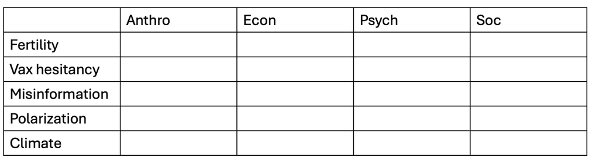

# Future 1: Empire

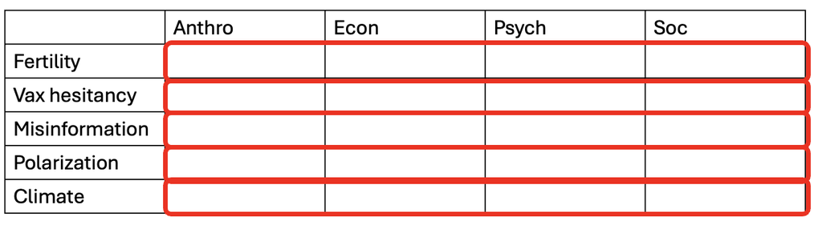

## The aspiration

> The conceptual, empirical, and mathematical techniques of cultural evolution and gene-culture coevolution should be part of the toolkit of all human scientists, biologists, and social scientists alike.

— Boyd & Richerson (2024, *PNAS*)

> We now have a common language and unifying theoretical framework for understanding human behavior across disciplines that once spoke past one another.

— Henrich (CES 2026 program)

## Why the desire is understandable

[figure not shown]

## Lesson I: Harvard, 1946

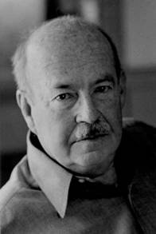

## Lesson II: Sociobiology, 1975

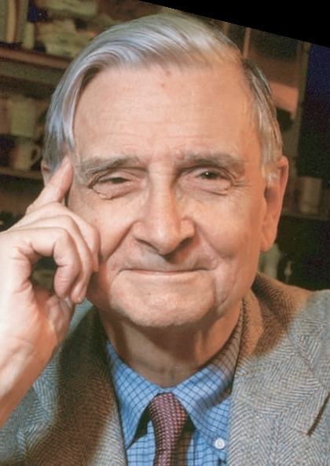

## Empire is… unlikely

[figure not shown]

## A reluctant verdict

The empire aspiration is **intellectually laudable** but **institutionally naïve**.

# Future 2: Discipline

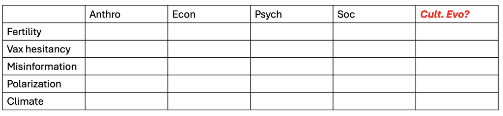

## What a discipline requires

- Departments that can hire, promote, and grant tenure
- Degree programs producing students who identify primarily with the field
- A career path that doesn’t require a disciplinary home elsewhere
- Sufficient consensus on core content to define a curriculum

## Lessons III: Cognitive science

[figure not shown]

## The Department of Cultural Evolution?

[figure not shown]

# Future 3: Field

## Topical field

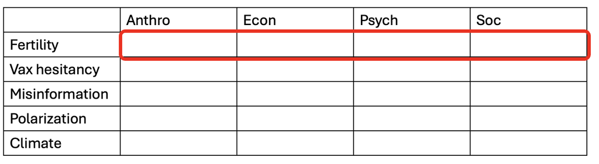

## Methods field

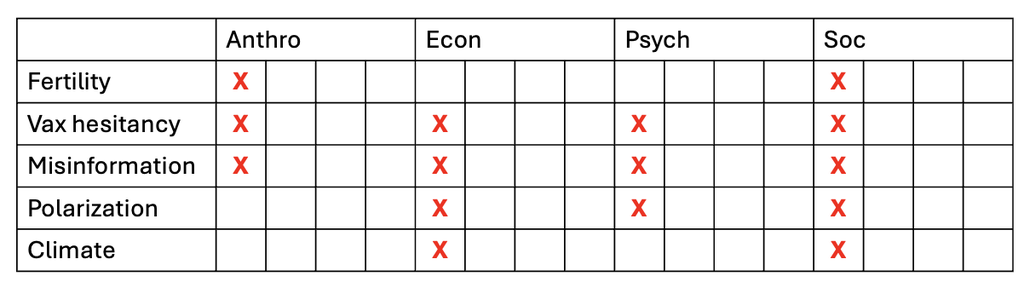

## Why demography worked

[figure not shown]

## The big tent

**Demography**

- Organized around **outcomes**
- Theory-agnostic at field level
- Methods + data as shared infrastructure
- “Bring your own theory”

**Cultural Evolution**

- Organized around **theory** (or relationships!)
- Theoretical allegiance often implied
- Methods less coherent as package
- “Adopt our framework”

## How demography built infrastructure

| Element | When | Significance |
| --- | --- | --- |
| Population Association of America | 1931 | Professional home, annual meeting |
| Office of Population Research, Princeton | 1936 | Dedicated training + research center |
| *Demography* journal | 1964 | Multi-disciplinary flagship |
| NICHD founding | 1963 | Dedicated federal funding stream |
| ICPSR summer training | 1970s+ | Cross-disciplinary cohort-building |

## Why networks worked

[figure not shown]

## How networks built infrastructure

| Element | When | Significance |
| --- | --- | --- |
| INSNA | 1977 | Professional home for dispersed, cross-disciplinary researchers |
| *Social Networks* journal | 1978 | Methods-focused flagship; no topical restriction |
| Sunbelt conference | 1981 | Open annual meeting; cross-disciplinary cohort-building |
| UCINET software | early 1980s | Standardized toolkit; lowered entry barrier across disciplines |
| Wasserman & Faust | 1994 | Canonical methods text; made the toolkit learnable and teachable |

# Features of a field

|  | Demography | Networks | Cultural Evolution |
| --- | --- | --- | --- |
| **Organization** | PAA (1931) | Sunbelt (1981) | CES (2016) |
| **Journal(s)** | *Demography* | *Social Networks* | ??? |
| **Topics** | Fertility, mortality, migration | Everything! | Cultural change, transmission, cooperation |
| **Concepts** | Population | Relations vs. essences | Population thinking, transmission, selection |
| **Methods** | Life tables, APC, survival | Centralities, ERGMs, “hairballs” | Diffusion models, transmission chains |

## Candidates

What do we have that is **distinctive** and **teachable**?

- “culture”
- population thinking
- dynamism
- formalism
- simulations
- “attractors” (?)

## What we have

- CES as organizational home
- Formal modeling toolkit: biased transmission, cultural group selection, drift, guided variation
- Comparative quantitative methods
- Some policy relevance: misinformation, norm change, public health behavior

## What we lack

- Methods not yet packaged as a coherent, learnable toolkit
- No flagship journal with cross-disciplinary authority
- Field currently held together by **personal networks**, not institutions
- Junior scholars face structural bind: CE identity can be a **job market liability**
- Internal theoretical disputes make shared curriculum hard to define

# The movement

## Movements need more than ideas

[figure not shown]

## Movement principles

- **senior scholars** take the risks and invest institutionally
- juniors orient strongly to **disciplines**
- students share *texts* and *methods* **across disciplines**
- networks, beliefs, and identities aren’t enough
- organize and institutionalize
  - syllabi
  - methods training and texts
  - journals

## Summary questions for field building

- Do we want to be a **topical field** or a **methods field**?
- What do we want students to **KNOW**?
- Who should **PUBLISH** their papers?
- Where should they **GO**?
- Who should **PAY** them when they’re done?

## The real question

[figure not shown]